# Phosphorus-Use Efficiency (PUE): a distribution check

- Show All Code
- Hide All Code
- View Source

Is PUE one long-tailed/Gaussian distribution, or a bimodal mixture of the two phosphorus treatments? With PUE performance across environments in beeswarm + boxplot style.

Author

Fausto Rodriguez Zapata

Published

June 29, 2026

# 1 The question

`PUE` (phosphorus-use efficiency) in `data/multilocation.csv` looked suspicious — a very flat, high-variance spread that could be a long tail or a wide Gaussian. The hypothesis (Stelio) is that it is really **bimodal**, one mode per **phosphorus condition**: P-stress vs. no stress.

That is exactly what the data say. PUE is computed as grain yield per unit applied phosphorus,

$$\text{PUE} = \frac{\text{GY (kg/ha)}}{\text{P input (kg/ha)}},$$

so the applied P is recoverable as `GY * 1000 / PUE`. It collapses to **two discrete values with zero within-location variance** — `10 kg/ha` (stress) at three environments (CHOKWE STS, NHACOONGO, SUSSUNDENGA) and `50 kg/ha` (optimal) at the other two (CHOKWE OPT, MANIQUENIQ) — which is carried in the `p_input` and `treatment` columns. The small stress denominator inflates PUE, so the upper mode is simply the stress environments.

```r
library(tidyverse)
library(ggbeeswarm)   # geom_quasirandom — beeswarm points
library(knitr)
library(kableExtra)
```

```r
hybrids <- read_csv("data/multilocation.csv", show_col_types = FALSE) %>%
  filter(gen != 0) %>%                       # drop the NAMULONGUE check
  mutate(
    env       = factor(env),
    treatment = factor(treatment, levels = c("Optimal", "Stress"))
  )

# Shared style: base_size 14, transparent boxplots, beeswarm points (the inv4m look,
# built on base ggplot2 theme_classic() — no ggpubr needed).
pue_theme <- theme_classic(base_size = 14) +
  theme(
    plot.title      = element_text(size = 14, face = "bold", hjust = 0.5),
    plot.margin     = margin(t = 20, r = 8, b = 5, l = 5, unit = "pt"),
    axis.title.y    = element_text(size = 12),
    axis.title.x    = element_blank(),
    axis.text.x     = element_text(size = 11, face = "bold", color = "black",
                                   angle = 30, hjust = 1),
    axis.text.y     = element_text(size = 10),
    legend.position = "top"
  )

trt_pal <- c("Optimal" = "#2c7fb8", "Stress" = "#d95f0e")
```

# 2 Performance across Environments

PUE for the 49 line × tester hybrids in each environment, drawn in the **beeswarm + transparent-boxplot** style: the data points sit in the background (`geom_quasirandom`) with a transparent boxplot in front (`alpha = 0`), coloured by phosphorus **treatment**. The three stress environments (orange) stand far above the two optimal sites — the visual signature of the bimodality.

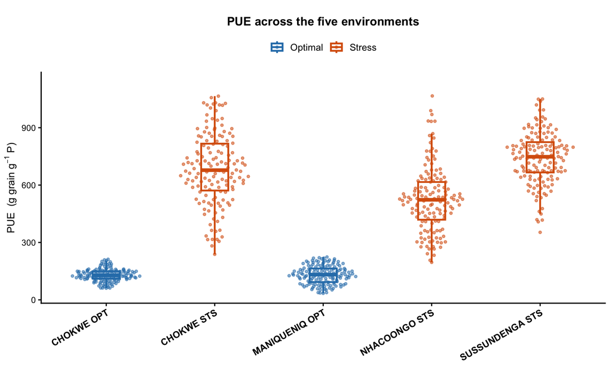

```r
ggplot(hybrids, aes(x = env, y = PUE, color = treatment)) +
  geom_quasirandom(size = 1.1, alpha = 0.55, width = 0.32) +          # points: background
  geom_boxplot(width = 0.25, linewidth = 1.0, alpha = 0,              # transparent box: front
               outlier.shape = NA) +
  scale_color_manual(values = trt_pal, name = NULL) +
  scale_y_continuous(expand = expansion(mult = c(0.05, 0.12))) +
  labs(title = "PUE across the five environments",
       y = expression("PUE  (g grain " * g^{-1} * " P)")) +
  pue_theme
```

# 3 Is PUE bimodal?

Pooled across environments, PUE is clearly **two humps**, not one. Splitting by `treatment` shows each treatment is its own well-separated, roughly unimodal cluster — so the overall bimodality is **entirely** the optimal-vs-stress contrast, nothing within a P regime.

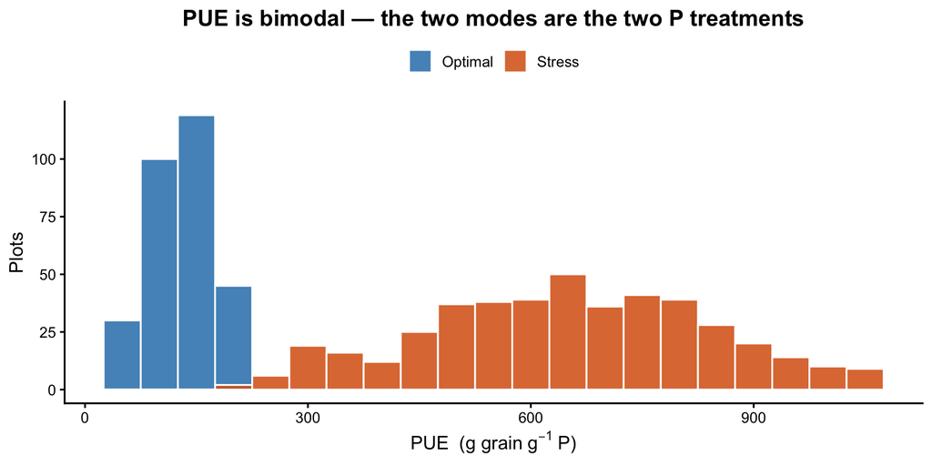

```r
ggplot(hybrids, aes(x = PUE, fill = treatment)) +
  geom_histogram(binwidth = 50, color = "white", alpha = 0.85,
                 position = "identity") +
  scale_fill_manual(values = trt_pal, name = NULL) +
  labs(title = "PUE is bimodal — the two modes are the two P treatments",
       x = expression("PUE  (g grain " * g^{-1} * " P)"), y = "Plots") +
  theme_classic(base_size = 13) +
  theme(legend.position = "top",
        plot.title = element_text(face = "bold", hjust = 0.5))
```

```r
hybrids %>%
  group_by(Treatment = treatment, `P input (kg/ha)` = p_input) %>%
  summarise(n = n(),
            `mean PUE` = round(mean(PUE), 0),
            `sd`       = round(sd(PUE), 0),
            min        = round(min(PUE), 0),
            max        = round(max(PUE), 0),
            .groups = "drop") %>%
  kable(caption = "PUE summary by phosphorus treatment. The stress site's 10 kg/ha denominator (vs 50) is what lifts its PUE into the upper mode.") %>%
  kable_styling(bootstrap_options = c("striped", "hover", "condensed"),
                full_width = FALSE)
```

PUE summary by phosphorus treatment. The stress site's 10 kg/ha denominator (vs 50) is what lifts its PUE into the upper mode.

| Treatment | P input (kg/ha) | n | mean PUE | sd | min | max |
| --- | --- | --- | --- | --- | --- | --- |
| Optimal | 50 | 294 | 131 | 41 | 34 | 224 |
| Stress | 10 | 441 | 650 | 189 | 196 | 1066 |

**Reading.** PUE is not a single skewed/Gaussian distribution — it is a **mixture of two P treatments**. PUE (and the other efficiency ratios) are therefore only comparable *within* a phosphorus regime; pooling optimal and stress plots is what produced the flat, high-variance “distribution” that looked wrong. For any model, the P treatment belongs in the design (here it is absorbed by the fixed `env` term, since `CHOKWE OPT` and `CHOKWE STS` are distinct environments).